# Exploratory Analysis

## Access to Parks and Green Spaces in Seattle

### Authors

Kavya Rao, Maeve Zhu, Mina Trice

### Date

Spring 2024

### Abstract

For our project, we will analyze a dataset that contains data on every public park in the city of Seattle, specifically on what types of natural features and manmade amenities those parks contain. Our analysis will reveal details about the equal accessibility of the parks for citizens based on location and socioeconomic factors, what aspects of natural and recreational life are not facilitated in these parks, and even how wildlife-friendly the city is. This could be used to push the city government to enact change that makes its parks more accessible and useful for those who are not having their needs met.

### Keywords

Environment, parks & green spaces, accessibility

### Introduction

*How common is access to parks and green spaces in Seattle? In particular, do Seattle parks tend to be accessible for people with disabilities?*

*What natural features and manmade amenities are most and least available in Seattle parks? What is the most accessible facility in Seattle parks?*

*Does the accessibility of parks and their important features vary by location within Seattle? Are the green areas concentrated in certain areas of the city or widely distributed?*

These questions are important because access to parks and green spaces for people in urban environments is proven to have a measurable impact on their mental and physical health. However, most cities were not planned and built with this in mind, so access to these green spaces can be skewed based on location. This, in turn, is determined by socioeconomic factors and historical practices such as redlining. Furthermore, the types of amenities the parks offer to users, as well as how well-maintained they are, can encourage or discourage residents from making full use of the parks. Residents require different types of parks, from child-friendly to dog-friendly to neither one, and so may not be able to utilize green spaces that do not fit their needs.

### Related Work

In regards to parks and green spaces in urban areas, recent studies have further proved their importance, including locally in Seattle. A case study led by the University of Washington investigated Seattle’s biggest park, Discovery Park. When locals were surveyed on their most meaningful experience at the park, some of the main keywords included “watching birds”, “listening to waves at the beach”, “spotting wildlife”. This indicates that the wildness of Discovery Park, and urban parks in general, are important for one’s physical and mental wellbeing. (Lev et al., 2020)

Lev, E., Kahn, P. H., Chen, H., & Esperum, G. (2020). Relatively wild urban parks can promote human resilience and flourishing: A case study of discovery park, Seattle, Washington. Frontiers in Sustainable Cities, 2. https://doi.org/10.3389/frsc.2020.00002

The way that urban access to green spaces is divided based on socioeconomic factors can exacerbate the impacts of those same factors. For example, in this review of how urban green spaces impact well-being (Jabbar, M., Yusoff, M. M., & Shafie, A. (2021). Assessing the role of urban green spaces for human well-being: A systematic review. GeoJournal, 87(5), 4405–4423. https://doi.org/10.1007/s10708-021-10474-7), the authors demonstrate that authentic physical fitness (being able to keep fit simply by living an active, walking-friendly lifestyle) is often determined by proximity to green spaces.

Veitch, J., Salmon, J., Crawford, D. et al. The REVAMP natural experiment study: the impact of a play-scape installation on park visitation and park-based physical activity. Int J Behav Nutr Phys Act 15, 10 (2018). https://doi.org/10.1186/s12966-017-0625-5 This article illustrates the importance of establishing a new play-scape that has the potential to positively influence park visitor numbers and park-based physical activity. This efficiently works for low-income family children. According to the visitors’ ages, there should be distinguished facilities for old and young people. To conclude, when the government invests more in public park amenities, it can increase the physical health and wellbeing of residents. Thus, this article can support our research purpose of investigating the amenities situation with parks in Seattle.

### The Dataset

There are questions of power in the data. The data includes the feature, but doesn’t include the condition of the equipment. The parks belong to the government, thus the maintenance condition reflects the department’s effort put in maintaining a high-quality park. We think the government’s power may prevent them from showing the real status of the equipment.

Meanwhile, there are three possible limitations and problems with the data. In the first column there are several repetitive contents because the data is describing each park’s features at a time. If a park has several features, the park’s name will appear several times in the first column. This means there are less than 1000 parks, most likely around 200-300 for the data analysis. The data includes the coordinates of the parks (latitude and longitude), but it does not include addresses or zip codes, which makes it more difficult to make a graph. This means that to analyze the data by location, we will have to make our own location groups through methods such as clustering certain latitudes and longitudes together. We will have to do more research on what location groups are relevant and how to imitate groups such as neighborhoods based only on the provided coordinates. One limitation includes the lack of data in regards to the quality of park features in Seattle. For example, the dataset includes “garden” as one of the features, but lacks the information regarding the quality of the garden. How big is the garden? Is it well maintained? Is it a garden for produce/community use, or simply one for show? The same lack of clarity applies to many other features such as tennis courts (How many courts are there?), hiking trails (How long is the trail?), views (What defines a “view”?) etc.

### Implications

Countless studies show that time in nature has tangible positive effects on mood, and that having access to parks also encourages more exercise and community building. All the people of Seattle deserve to have access to parks that facilitate this. Analyzing this dataset could show that certain amenities are clustered in some locations and not readily available in others. It could also show us that park location varies by social factors such as the income of certain areas. Furthermore, there are also implications about the biodiversity within the city, specifically whether it is wildlife-friendly. If too few parks are pesticide-free or contain hiking trails or waterfront, the park cannot be a safe and diverse wildlife corridor. This raises the question of whether enough parks are accessible for all citizens of Seattle as well as for wildlife.

In general, our findings could provide a direction for the city government as it prioritizes what aspects of its lands to work on. For example, they could possibly prioritize adding more greenery to parks without green features, or finding land for parks for people that do not have any access to them. Another example is that many of the provided features in the dataset relate to whether parks are child-friendly. This is important because child-friendliness encourages more people to make use of the park, and it is particularly important for children to have access to nature from a young age. Designers and policymakers could analyze this and choose to allocate funds to these features within Seattle’s parks.

### Limitations & Challenges

There are a few challenges and limitations in terms of our project. One limitation of this project includes the fact that this only focuses on parks in one city. We chose Seattle due to proximity and relevance to our group, however we cannot measure or generalize our findings to other cities in Washington, or across the world. As a result, our findings are limited to only Seattle. Additionally, another challenge that this project runs into is how these park features may look in the future, especially with climate change. Our project cannot predict and account for how things will change over the years, such as certain features shutting down, climate change affecting trails or waterfront areas, or maintenance quality of a park declining. Another limitation is that we are unable to see the user’s experience from this project idea. We can see some parks with fancy features, however, when you are traveling there you may find a lot of homeless people living near the park. Sometimes, there are people playing extremely loud music and doing drugs near the viewpoint. These are the unseen problems when visitors actually travel there. To build a broader and human-centric project, we should collect user experience data including qualitative data such as descriptive words based on their impression of the park.

### Table

As we discussed the importance of wild parks in urban spaces, this table below shows parks with said features. To do this, we sorted parks with the words “woods” and “hiking trails” in the features column. This showcases the almost 60 parks in Seattle with a less urban, and more wild environment.

| …1 | Name | Location 1 | Feature_Desc |
| --- | --- | --- | --- |
| 1 | Arroyos Natural Area | 4120 Arroyo Dr SW (-122.387822, 47.505679) | Woods |
| 2 | Boren Park | 1606 15th Ave E (-122.311628, 47.635274) | Woods |
| 3 | Camp Long | 5200 35th Ave SW (-122.373161, 47.556242) | Hiking Trails, Woods |
| 4 | Carkeek Park | 950 NW Carkeek Park Rd (-122.379763, 47.712194) | Hiking Trails, Woods |
| 5 | Colman Park | 1800 Lake Washington Blvd S (-122.288612, 47.58547) | Woods |
| 6 | Cowen Park | 5849 15th Ave NE (-122.313072, 47.672596) | Hiking Trails, Woods |
| 7 | Crown Hill Glen | 8735 19th Ave NW (-122.381394, 47.693703) | Woods |
| 8 | David Rodgers Park | 2800 1st Ave W (-122.359484, 47.644135) | Woods |
| 9 | Dearborn Park | 2919 S Brandon St (-122.296225, 47.553389) | Hiking Trails, Woods |
| 10 | Discovery Park | 3801 Discovery Park Blvd (-122.415282, 47.66083) | Hiking Trails, Woods |
| 11 | Dr. Jose Rizal Park | 1007 12th Ave S (-122.318094, 47.593859) | Hiking Trails, Woods |
| 12 | Fauntleroy Park | 3951 SW Barton St (-122.383222, 47.5192) | Hiking Trails, Woods |
| 13 | Frink Park | 398 Lake Washington Blvd S (-122.290256, 47.599506) | Hiking Trails, Woods |
| 14 | Genesee Park and Playfield | 4316 S Genesee St (-122.278744, 47.564856) | Hiking Trails |
| 15 | Golden Gardens Park | 8498 Seaview Pl NW (-122.403454, 47.686852) | Hiking Trails |
| 16 | Green Lake Park | 7201 E Greenlake Dr N (-122.330394, 47.678938) | Woods |
| 17 | Hamilton Viewpoint Park | 1120 California Ave SW (-122.38907, 47.590748) | Woods |
| 18 | Harrison Ridge Greenbelt | 138 32nd Ave E (-122.290339, 47.619711) | Woods |
| 19 | Hitt’s Hill Park | 5234 37th Ave S (-122.28455, 47.554207) | Hiking Trails |
| 20 | Interlaken Park | 2451 Delmar Dr E (-122.308316, 47.636257) | Hiking Trails, Woods |
| 21 | Kinnear Park | 899 W Olympic Pl (-122.367207, 47.627317) | Hiking Trails, Woods |
| 22 | Kiwanis Memorial Preserve Park | 4441 Brygger Dr W (-122.401004, 47.66197) | Woods |
| 23 | Kiwanis Memorial Preserve Park | 4531 33rd Ave W (-122.403237, 47.660251) | Woods |
| 24 | Lake People Park (Xacua’bs) | 3100 S Bradford st (-122.292012, 47.569133) | Hiking Trails |
| 25 | Lakeridge Park | 10201 Holyoke Way S (-122.247429, 47.506033) | Hiking Trails, Woods |
| 26 | Lawton Park | 4005 27th Ave W (-122.391158, 47.655065) | Hiking Trails, Woods |
| 27 | Leschi Park | 201 Lakeside Ave. S (-122.286548, 47.600931) | Woods |
| 28 | Leschi-Lake Dell Natural Area | 3525 E Terrace St (-122.287835, 47.604695) | Hiking Trails |
| 29 | Licton Springs Park | 9536 Ashworth Ave N (-122.338735, 47.698542) | Hiking Trails, Woods |
| 30 | Lincoln Park | 8011 Fauntleroy Way SW (-122.396012, 47.531176) | Hiking Trails, Woods |
| 31 | Llandover Woods Greenspace | 14499 3rd Ave NW (-122.364545, 47.733024) | Woods |
| 32 | Madrona Park | 853 Lake Washington Blvd (-122.282679, 47.609299) | Hiking Trails, Woods |
| 33 | Magnolia Greenbelt | NA | Woods |
| 34 | Magnolia Park | 1461 Magnolia Blvd W (-122.398993, 47.632366) | Woods |
| 35 | Maple School Ravine | 1950 S Graham St (-122.308342, 47.551071) | Woods |
| 36 | Martha Washington Park | 6612 57th Ave S (-122.260054, 47.542398) | Hiking Trails |
| 37 | Matthews Beach Park | 5100 NE 93rd St (-122.271785, 47.694564) | Hiking Trails |
| 38 | Me-Kwa-Mooks Natural Area | 4100 Aikins Ave SW (-122.403424, 47.563782) | Woods |
| 39 | Me-Kwa-Mooks Park | 4503 Beach Dr SW (-122.404006, 47.563167) | Woods |
| 40 | Mt. Baker Park | 2521 Lake Park Dr S (-122.288481, 47.580957) | Hiking Trails, Woods |
| 41 | North Beach Park | 8999 24th Ave NW (-122.390258, 47.69471) | Woods |
| 42 | Northacres Park | 12718 1st Ave NE (-122.326124, 47.721775) | Hiking Trails, Woods |
| 43 | Northeast Queen Anne Greenbelt | Dexter Way N & Lynn St & Wheeler (-122.345011, 47.635866) | Hiking Trails, Woods |
| 44 | Pigeon Point Park | 4418 21st Ave SW (-122.356966, 47.563271) | Hiking Trails, Woods |
| 45 | Puget Boulevard Commons | NA | Woods |
| 46 | Puget Park | 4767 Puget Way SW (-122.356922, 47.558473) | Hiking Trails, Woods |
| 47 | Ravenna Park | 5520 Ravenna Ave NE (-122.305705, 47.671404) | Hiking Trails, Woods |
| 48 | Riverview Playfield | 7226 12th Ave SW (-122.348688, 47.54101) | Woods |
| 49 | SW Queen Anne Greenbelt | 12th Ave W & W Howe St (-122.373209, 47.633353) | Woods |
| 50 | Schmitz Preserve Park | 5551 SW Admiral Way (-122.400425, 47.574375) | Hiking Trails, Woods |
| 51 | Seola Park | 11399 Seola Beach Dr SW (-122.374332, 47.50039) | Woods |
| 52 | Seward Park | 5900 Lake Washington Blvd S (-122.250639, 47.54923) | Hiking Trails, Woods |
| 53 | St. Mark’s Greenbelt | 1500 Lakeview Blvd E (-122.322174, 47.63115) | Woods |
| 54 | Thornton Creek Park #1 | 13002 10th Ave NE (-122.307629, 47.707034) | Woods |
| 55 | Victory Creek Park | 1059 NE Northgate Way (-122.315554, 47.709155) | Woods |
| 56 | Viretta Park | 151 Lake Washington Blvd E (-122.282003, 47.61875) | Woods |
| 57 | Warren G. Magnuson Park | 7400 Sand Point Way NE (-122.255084, 47.680304) | Hiking Trails |
| 58 | Washington Park Arboretum | 2300 Arboretum Dr E (-122.294835, 47.636477) | Hiking Trails, Woods |
| 59 | Westcrest Park | 9000 8th Ave SW (-122.341719, 47.525783) | Hiking Trails, Woods |
| 60 | Woodland Park | 1000 N 50th St (-122.344218, 47.668906) | Woods |

### Chart 1

This scatterplot plots the distance of a park from the Seattle city center against how many different features the park has. It aims to provide a basic visualization of whether more varied and useful parks are more accessible to people in more central and urban or more peripheral and rural parts of Seattle.

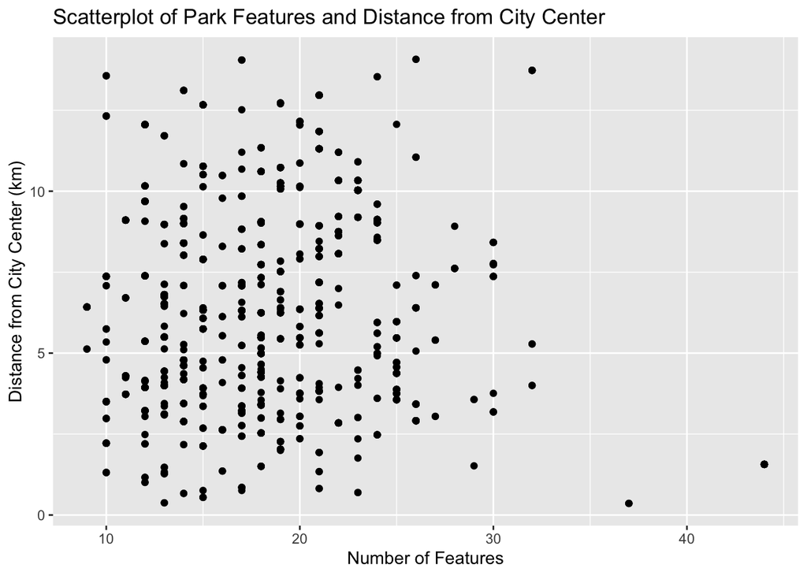

### Chart 2

We need bar charts to count the differences in the frequency of occurrence of each category. According to research, a variety of sports facilities help to improve the physical and mental health of the neighborhood. We found that the names of facilities that appear more than 25 times mostly include those related to sports fields and restrooms, while those that appear less than four times tend to have a variety of facilities depending on the location. Both water activities and skateboarding and zipline are less frequent because they require more park terrain. This is a side note to the diversity of sports facilities in Seattle’s parks.

```
## # A tibble: 42 × 2
##    Feature_Desc              Count
##    <chr>                     <int>
##  1 Tennis Court (Outdoor)      147
##  2 Play Area (ADA Compliant)   119
##  3 Baseball/Softball           114
##  4 View                        100
##  5 Paths                        98
##  6 Restrooms                    93
##  7 Soccer                       74
##  8 Waterfront                   59
##  9 Woods                        52
## 10 Basketball (Half)            49
## # ℹ 32 more rows
```

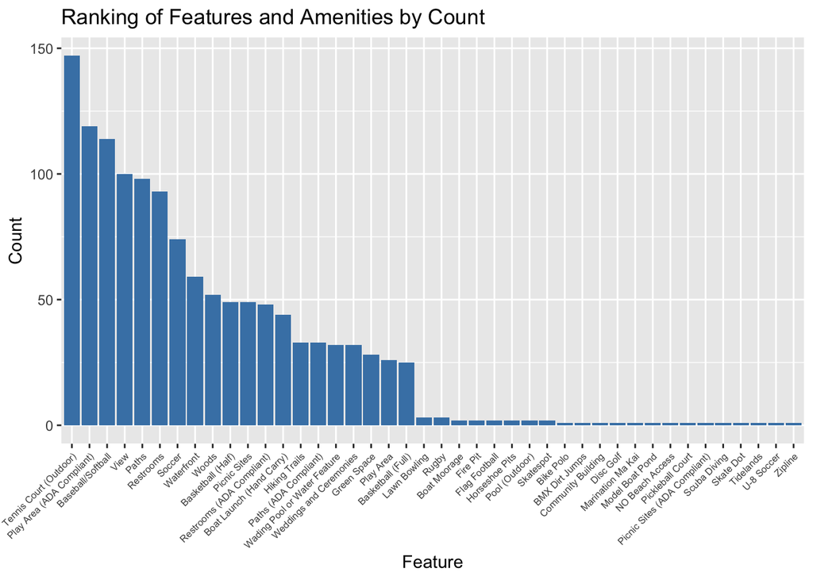

### Chart 3

This interactive map showcases the number of parks in Seattle with ADA compliant amenities. This includes play areas, paths and restrooms, with some parks including all three. As we discussed earlier, the importance of accessible features in parks are crucial for everyone’s enjoyment and equal accessibility to amenities. It is also important to be mindful of how we can go beyond these 128 parks w/ ADA compliant features.

[interactive chart not shown]